# Topic 4 Exercises: Classification

## 4.7.8

When k=1, the training error rate is 0%. Since the average error rate is 18%, the testing error rate must be 36%. This is higher than the testing error rate of 30% for the logistic regression, so we should prefer to use logistic regression in this case.

## 4.7.9

### Part a

p(X)/(1-p(X)) = 0.37, so we can express p(X) as p(X) = 0.37/(1+0.37), which equals about 0.27. On average, about 27% of people who have a 0.37 odds of defaulting on their credit card payment will actually default.

### Part b

p(X) = 0.16. p(X)/(1-p(X)) = 0.16/(1-0.16) = about 0.19. The odds that she will default is 0.19.

## Programming

## 4.7.11

### Part a

```r
library(ISLR)
library(MASS)
mpg01 <- rep(0, length(Auto$mpg))
mpg01[Auto$mpg > median(Auto$mpg)] <- 1
Auto <- data.frame(Auto, mpg01)
```

### Part b

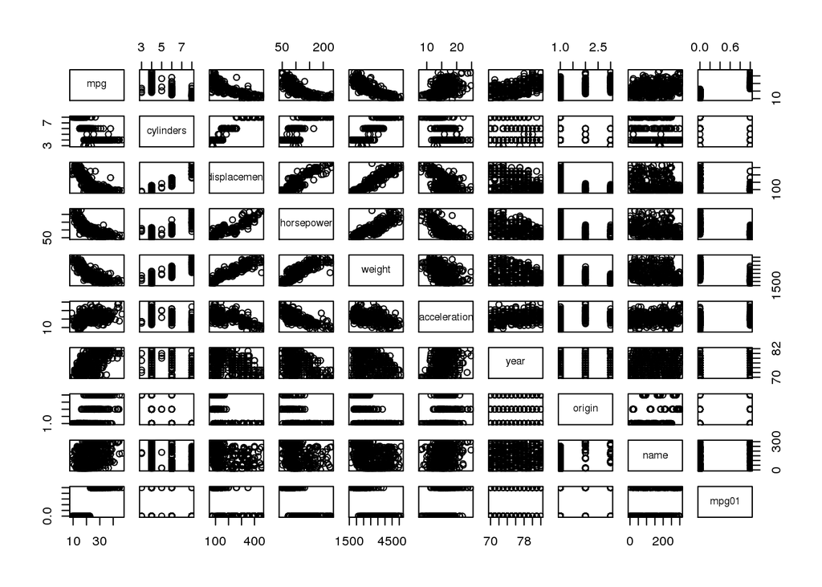

```r
pairs(Auto)
```

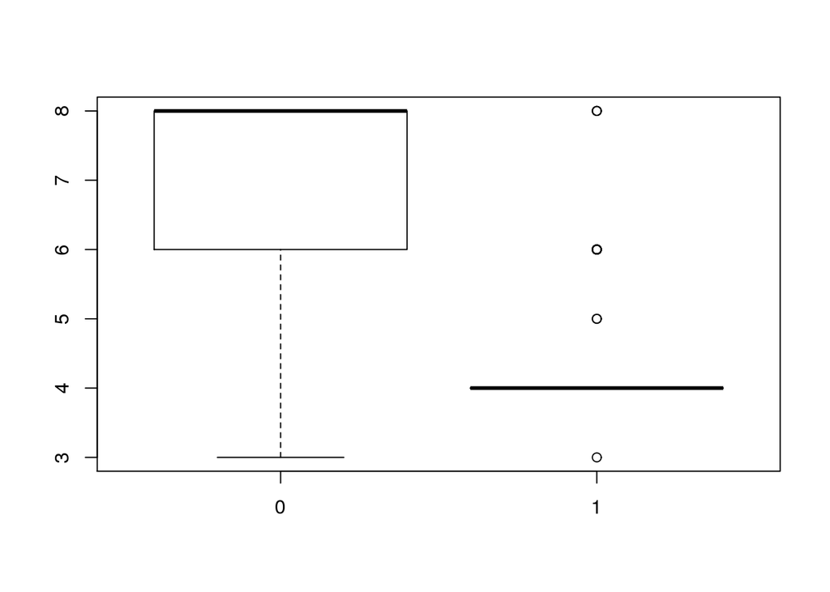

```r
boxplot(cylinders ~ mpg01, data = Auto)
```

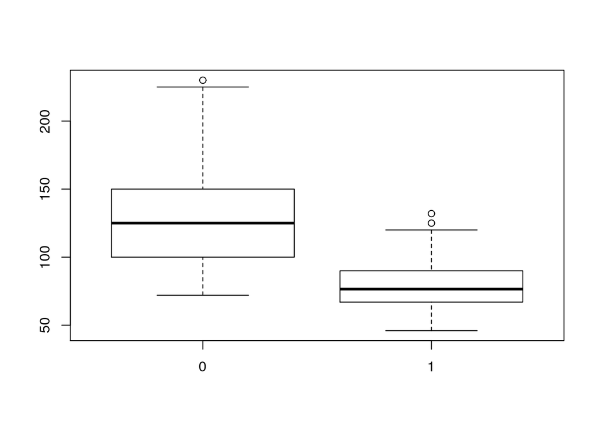

```r
boxplot(horsepower ~ mpg01, data = Auto)
```

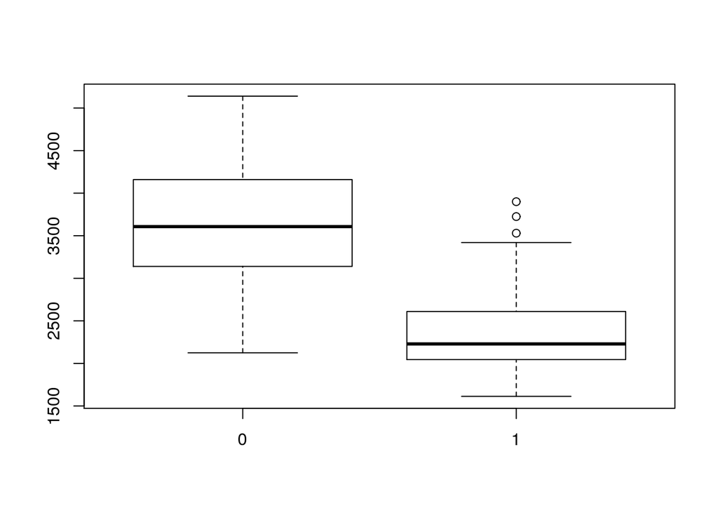

```r
boxplot(weight ~ mpg01, data = Auto)
```

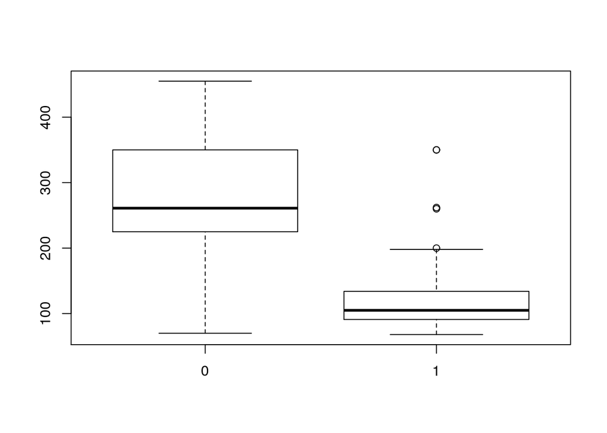

```r
boxplot(displacement ~ mpg01, data = Auto)
```

It appears that cylinders, horsepower, weight, and displacement are most useful in predicting mpg01.

### Part c

```r
training <- (Auto$year %% 2 == 0)
For_Training <- Auto[training, ]
For_Testing <- Auto[!training, ]
mpg01_training <- mpg01[training]
mpg01_testing <- mpg01[!training]
```

### Part d

```r
LDA <- lda(mpg01 ~ cylinders + horsepower + weight + displacement, data = Auto, subset = training)
LDA_predicted <- predict(LDA, For_Testing)
mean(LDA_predicted$class != mpg01_testing)
```

```
## [1] 0.1263736
```

The test error obtained is about 12.6%.

### Part e

```r
QDA <- qda(mpg01 ~ cylinders + horsepower + weight + displacement, data = Auto, subset = training)
QDA_predicted <- predict(QDA, For_Testing)
mean(QDA_predicted$class != mpg01_testing)
```

```
## [1] 0.1318681
```

The test error obtained is about 13.2%.

### Part f

```r
GLM <- glm(mpg01 ~ cylinders + horsepower + weight + displacement, data = Auto, subset = training)
GLM_predicted <- predict(GLM, For_Testing)
GLM_predicted_2 <- rep(0, length(GLM_predicted))
GLM_predicted_2[GLM_predicted > 0.5] <- 1
mean(GLM_predicted_2 != mpg01_testing)
```

```
## [1] 0.1263736
```

The test error obtained is about 12.6%.

### Part g

```r
library(class)
KNN_training <- cbind(Auto$cylinders, Auto$horsepower, Auto$weight, Auto$displacement)[training,]
KNN_testing <- cbind(Auto$cylinders, Auto$horsepower, Auto$weight, Auto$displacement)[!training,]
set.seed(1)
KNN_predicted <- knn(KNN_training, KNN_testing, mpg01_training, k=1)
mean(KNN_predicted != mpg01_testing)
```

```
## [1] 0.1538462
```

When k=1, the test error obtained is about 15.3%.

```r
KNN_predicted <- knn(KNN_training, KNN_testing, mpg01_training, k=10)
mean(KNN_predicted != mpg01_testing)
```

```
## [1] 0.1648352
```

When k=10, the test error obtained is about 16.5%.

```r
KNN_predicted <- knn(KNN_training, KNN_testing, mpg01_training, k=100)
mean(KNN_predicted != mpg01_testing)
```

```
## [1] 0.1428571
```

When k=100, the test error obtained is about 14.3%.

## 4.7.13

```r
crim01 <- rep(0, length(Boston$crim))
crim01[Boston$crim > median(Boston$crim)] <- 1
Boston <- data.frame(Boston, crim01)

training <- 1:(length(Boston$crim)/2)
testing <- ((length(Boston$crim)/2)+1):length(Boston$crim)
For_Training <- Boston[training,]
For_Testing <- Boston[testing,]
crim01_testing <- crim01[testing]
crim01_training <- crim01[training]

GLM <- glm(crim01 ~ tax, data = Boston, family = binomial, subset = training)
GLM_predicted <- predict(GLM, For_Testing, type = "response")
GLM_predicted_2 <- rep(0, length(GLM_predicted))
GLM_predicted_2[GLM_predicted > 0.5] <- 1
mean(GLM_predicted_2 != crim01_testing)
```

```
## [1] 0.173913
```

In this case, the test error obtained is about 17.4%.

```r
GLM <- glm(crim01 ~ age + zn + tax + black, data = Boston, family = binomial, subset = training)
GLM_predicted <- predict(GLM, For_Testing, type = "response")
GLM_predicted_2 <- rep(0, length(GLM_predicted))
GLM_predicted_2[GLM_predicted > 0.5] <- 1
mean(GLM_predicted_2 != crim01_testing)
```

```
## [1] 0.1462451
```

```r
LDA <- lda(crim01 ~ tax, data = Boston, subset = training)
LDA_predicted <- predict(LDA, For_Testing)
mean(LDA_predicted$class != crim01_testing)
```

```
## [1] 0.173913
```

In this case, the test error obtained is about 17.4%, the same as with logistic regression for this model.

```r
LDA <- lda(crim01 ~ age + zn + tax + black, data = Boston, subset = training)
LDA_predicted <- predict(LDA, For_Testing)
mean(LDA_predicted$class != crim01_testing)
```

```
## [1] 0.1501976
```

In this case, the test error obtained is about 15.0%. As with the logistic regression, the second LDA performs better, but not much better considering we added 3 predictors.

```r
KNN_training <- cbind(Boston$age, Boston$zn, Boston$tax, Boston$black)[training,]
KNN_testing <- cbind(Boston$age, Boston$zn, Boston$tax, Boston$black)[testing,]
set.seed(1)
KNN_predicted <- knn(KNN_training, KNN_testing, crim01_training, k=1)
mean(KNN_predicted != crim01_testing)
```

```
## [1] 0.4545455
```

When k=1, the test error obtained is about 45.5%.

```r
KNN_predicted <- knn(KNN_training, KNN_testing, crim01_training, k=10)
mean(KNN_predicted != crim01_testing)
```

```
## [1] 0.1185771
```

When k=10, the test error obtained is about 11.9%.

```r
KNN_predicted <- knn(KNN_training, KNN_testing, crim01_training, k=100)
mean(KNN_predicted != crim01_testing)
```

```
## [1] 0.4980237
```